# East Bay Public Schools Performance and Equity Analysis

## Performance comparison for marginalized communities

This graph illustrates that Migrant Education, Socioeconomically Disadvantaged, and English Learners generally perform lower than the overall student population across all districts.

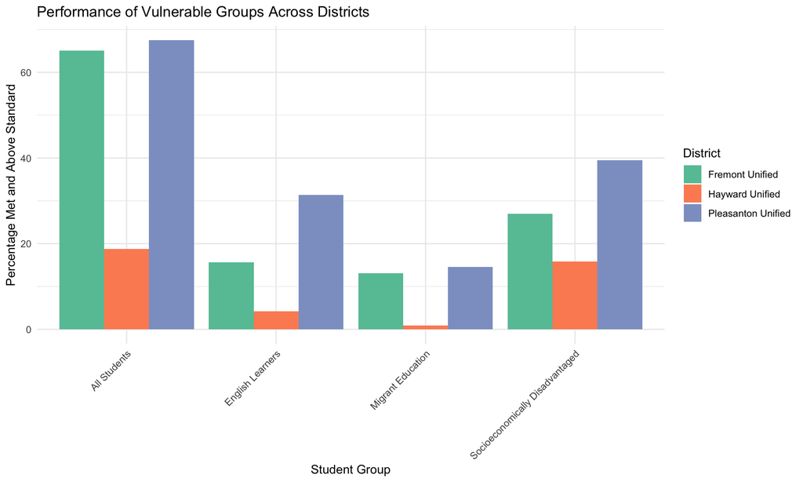

```r
vulnerable_groups <- cast_data_filtered %>%
  add_district_names() %>%
  filter(`Student Group ID` %in% c(160, 31, 128, 1)) %>%  # Include All Students (1) for comparison
  mutate(`Student Group` = case_when(
    `Student Group ID` == 160 ~ "Migrant Education",
    `Student Group ID` == 31 ~ "Socioeconomically Disadvantaged",
    `Student Group ID` == 128 ~ "English Learners",
    `Student Group ID` == 1 ~ "All Students"
  )) %>%
  select(DistrictName, `Student Group`, `Percentage Standard Met and Above`) %>%
  mutate(`Percentage Standard Met and Above` = as.numeric(`Percentage Standard Met and Above`))

ggplot(vulnerable_groups, aes(x = `Student Group`, y = `Percentage Standard Met and Above`, fill = DistrictName)) +
  geom_bar(stat = "identity", position = "dodge") +
  scale_fill_brewer(palette = "Set2") +
  labs(title = "Performance of Vulnerable Groups Across Districts",
       x = "Student Group",
       y = "Percentage Met and Above Standard",
       fill = "District") +
  theme_minimal() +
  theme(axis.text.x = element_text(angle = 45, hjust = 1))
```

## Graduation Rates for English Learners Compared to Overall

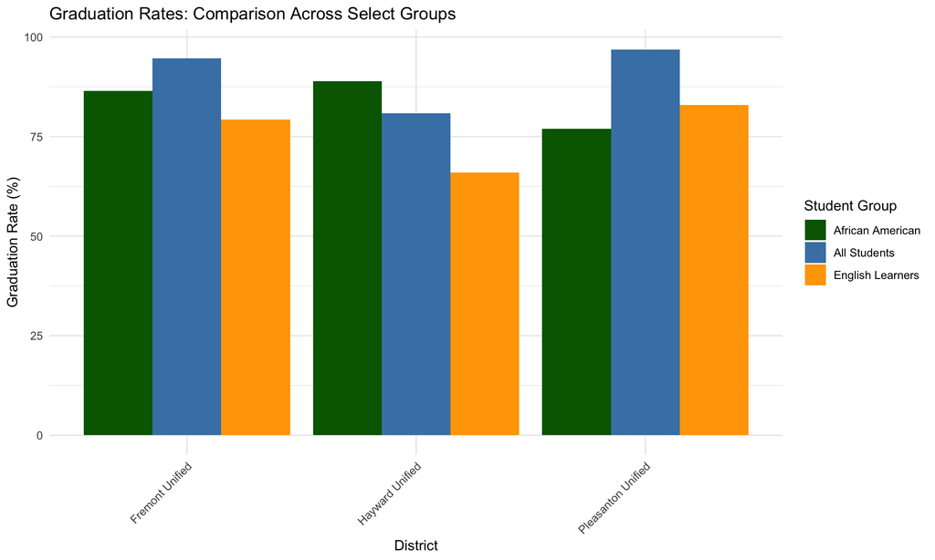

```r
library(dplyr)
library(ggplot2)
library(forcats)

# Prepare the data
graduation_rates <- acgr_data_filtered %>%
  add_district_names() %>%
  filter(ReportingCategory %in% c("SE", "TA", "RB")) %>%  # SE for English Learners, TA for All Students, RB for African American
  select(DistrictName, ReportingCategory, `Regular HS Diploma Graduates (Rate)`) %>%
  mutate(
    `Regular HS Diploma Graduates (Rate)` = as.numeric(gsub("%", "", `Regular HS Diploma Graduates (Rate)`)),
    ReportingCategory = case_when(
      ReportingCategory == "SE" ~ "English Learners",
      ReportingCategory == "TA" ~ "All Students",
      ReportingCategory == "RB" ~ "African American",
      TRUE ~ ReportingCategory
    )
  )

# Create the plot
ggplot(graduation_rates, aes(x = DistrictName, y = `Regular HS Diploma Graduates (Rate)`, fill = ReportingCategory)) +
  geom_bar(stat = "identity", position = "dodge") +
  scale_fill_manual(values = c("All Students" = "steelblue", "English Learners" = "orange", "African American" = "darkgreen")) +
  labs(title = "Graduation Rates: Comparison Across Select Groups",
       x = "District",
       y = "Graduation Rate (%)",
       fill = "Student Group") +
  theme_minimal() +
  theme(axis.text.x = element_text(angle = 45, hjust = 1))
```

```r
# Print summary statistics
summary_stats <- graduation_rates %>%
  group_by(ReportingCategory) %>%
  summarize(
    Mean_Rate = mean(`Regular HS Diploma Graduates (Rate)`, na.rm = TRUE),
    SD_Rate = sd(`Regular HS Diploma Graduates (Rate)`, na.rm = TRUE)
  )

print(summary_stats)
```

```
## # A tibble: 3 × 3
##   ReportingCategory Mean_Rate SD_Rate
##   <chr>                 <dbl>   <dbl>
## 1 African American       83.3    6.86
## 2 All Students           84.6   11.1
## 3 English Learners       70.2   13.0
```

# Recommendations

## For Policymakers

1. Targeted Resource Allocation:
   - Allocate additional resources to Hayward Unified, which shows lower performance across most metrics compared to Fremont and Pleasanton.
   - Focus on programs that support English Learners and socioeconomically disadvantaged students, as these groups consistently show lower performance.
2. Early Intervention Programs:
   - Implement and fund early intervention programs in elementary and middle schools, particularly in Hayward Unified, to address achievement gaps before they widen in high school.
3. Chronic Absenteeism:
   - Develop district-wide policies to address chronic absenteeism, particularly for marginalized groups. This could include improved transportation options, health services, and family outreach programs.

## For School Administrators

1. Data-Driven Decision Making:
   - Regularly analyze performance data disaggregated by demographic groups to identify specific areas of need and track progress.
   - Use this data to inform curriculum adjustments and resource allocation within schools.
2. Professional Development:
   - Provide teachers with cultural competency training to better support diverse student populations.
   - Offer training on differentiated instruction techniques to address varying learning needs.

## For Teachers

1. Culturally Responsive Teaching:
   - Incorporate culturally relevant content and examples in lesson plans to engage students from diverse backgrounds.
   - Create an inclusive classroom environment that values and respects all cultural backgrounds.
2. Individualized Support:
   - Implement personalized learning plans for students from marginalized groups who are struggling academically.
   - Provide additional after-school or weekend tutoring sessions targeted at closing achievement gaps.

## For Parents and Community Members

1. Engagement and Advocacy:
   - Encourage active participation in school board meetings and parent-teacher associations, especially from underrepresented communities.
   - Advocate for increased funding and resources for programs supporting marginalized students.
2. Mentorship Programs:
   - Establish community mentorship programs pairing successful individuals from marginalized backgrounds with students to provide guidance and role models.
3. Home-School Partnerships:
   - Develop programs to strengthen the connection between homes and schools, such as parent education workshops on supporting student learning at home.

## Cross-District Collaboration

- Establish a tri-district taskforce to share best practices, particularly focusing on how Pleasanton and Fremont can share successful strategies with Hayward.
- Implement a student exchange program allowing students from marginalized groups to experience learning environments in higher-performing schools.

## Technology and Access

- Ensure all students, especially those from marginalized communities, have access to necessary technology and internet connectivity for remote learning and homework completion.
- Implement digital literacy programs for both students and parents to maximize the use of available technological resources.

## Mental Health and Well-being

- Increase the number of school counselors and mental health professionals, especially in schools with higher proportions of marginalized students.
- Implement social-emotional learning programs to help students develop resilience and coping skills.

# Conclusion

By implementing these recommendations, we aim to see measurable improvements in the performance of students from marginalized communities across all three districts over the next 3 years. Regular monitoring and adjustment of these strategies will be crucial to ensure their effectiveness and to make necessary modifications as needs evolve.